# Pearson Audition Project

Tomasz Dąbrowski

20th of October, 2016

## Introduction

This document presents exploratoy research of Pearson’s e-learning platform data. It will contain research hypotheses, descriptive statisitics, hypothesis testing, data visualisation, and chunks of code with the resulting output.

### Loading data

Let’s load a data from working directory and then take a look how it looks like.

```r
dt <- read.csv("data.csv", header = T, sep = ",")
head(dt)
```

```
##   learner_id country in_course     unit avg_score completion inv_rate
## 1         39      PL         t        1     0.200      0.100    0.000
## 2         39      PL         t        3     1.000      0.087    0.000
## 3         39      PL         t REVIEW 2     0.100      0.273    0.000
## 4         41      PL         t        1     0.877      0.350    0.381
## 5         41      PL         t        3     0.000      0.087    0.000
## 6         41      PL         t        5     0.000      0.087    1.000
```

Let’s see how many variables and observations are in the spreadsheet.

```r
dim(dt)
```

```
## [1] 81432     7
```

What are the types of the variables?

```r
str(dt)
```

```
## 'data.frame':    81432 obs. of  7 variables:
##  $ learner_id: int  39 39 39 41 41 41 41 802 802 802 ...
##  $ country   : Factor w/ 87 levels "","AD","AF","AG",..: 62 62 62 62 62 62 62 1 1 1 ...
##  $ in_course : Factor w/ 2 levels "f","t": 2 2 2 2 2 2 2 2 2 2 ...
##  $ unit      : Factor w/ 17 levels "1","10","11",..: 1 6 14 1 6 8 14 1 5 6 ...
##  $ avg_score : num  0.2 1 0.1 0.877 0 0 0 0.954 0.877 0.883 ...
##  $ completion: num  0.1 0.087 0.273 0.35 0.087 0.087 0.182 1 1 0.739 ...
##  $ inv_rate  : num  0 0 0 0.381 0 1 0 0 0 0 ...
```

### Understanding variables

All right, we have some information about data. It’s time to make some assumptions. Which variables look interesting? They are described in the attached document. Let’s have them here…

- **learner** id : anonymized student identifier
- **country** : country code of the student
- **in_course** : “t” if the student belongs to course taught by a teacher (as opposed to studying alone)
- **unit** : number or name of a unit (chapter) in the workbook
- **avg_score** : average percentage score on all activities within a given unit
- **completion** : the percentage of activities completed in a given unit, out of all activities available in that unit
- **inv_rate** : This is the extent to which a student deviates from the suggested order of activities by the pedagogy experts within a given unit. A value of zero indicates no departure from the suggested order, a value of one indicates a complete reversal of the order.

The **country** variable looks promising. We will be able to compare performance of students across different countries. Thanks to **in_course** variable, we will assesss efficiency of teachers. **unit**, **avg_score** and **completion** variables should tell us something about difficulty of certain units. **inv_rate** seems to be very interesting. Do ‘rebel’ students perform better than ‘regular’ students? Are some countries more rebelious than others? Does teacher presence impact the way students learn?

Questions worth asking:

1. Which units are the hardest? Which have the smallest completion rate?
2. Which country performs the best? What country has most rebelious students?
3. Does having a teacher improve performance?
4. What affects the most being succesfull? Country? Inverse index? Having a teacher?

## Exploring data

#### Question 1: Which units are the hardest? Which have the smallest completion rate?

```r
library(plyr)
library(ggplot2)
#install.packages('ggthemes', dependencies = TRUE)
library(ggthemes)
theme_set(theme_gray(10))

levels(dt$unit)
```

```
##  [1] "1"              "10"             "11"             "12"
##  [5] "2"              "3"              "4"              "5"
##  [9] "6"              "7"              "8"              "9"
## [13] "REVIEW 1"       "REVIEW 2"       "REVIEW 3"       "REVIEW 4"
## [17] "VIDEO PODCASTS"
```

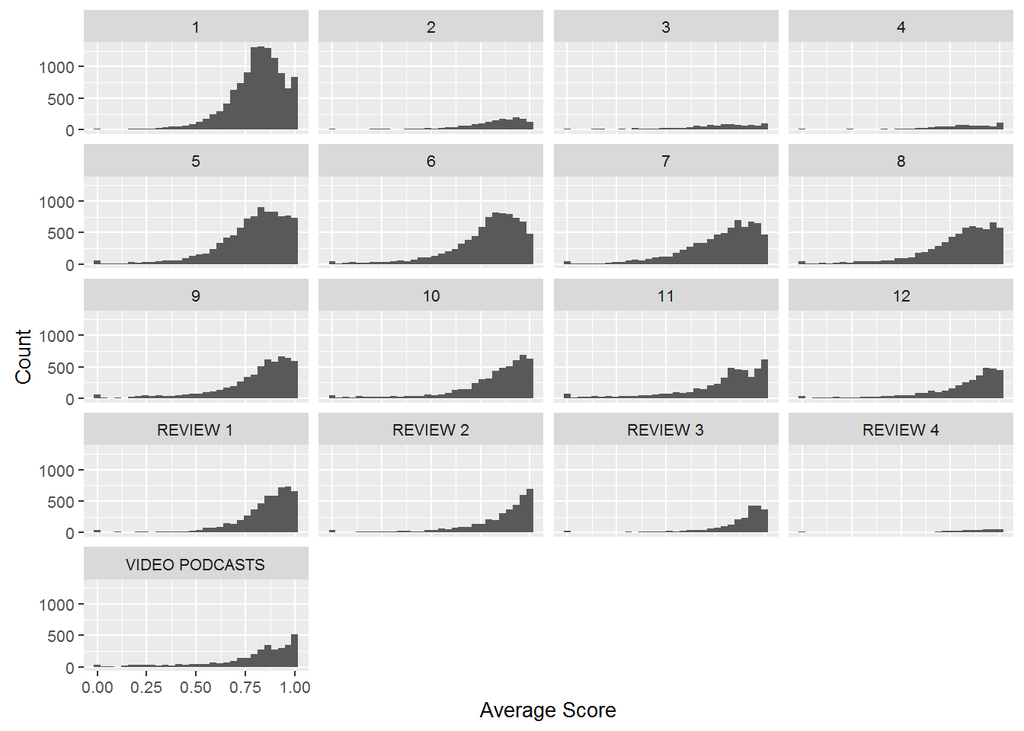

```r
levels(dt$unit) <- c("1", "2", "3", "4", "5", "6", "7", "8", "9", "10", "11", "12", "REVIEW 1", "REVIEW 2", "REVIEW 3", "REVIEW 4", "VIDEO PODCASTS")  #better levels order

unit_scores <- qplot(x = avg_score, data = dt) +
  facet_wrap(~unit, ncol = 4) +
  labs(x = "Average Score", y = "Count")
unit_scores
```

```r
ggsave("scores_vs_unit.png", plot = unit_scores)
```

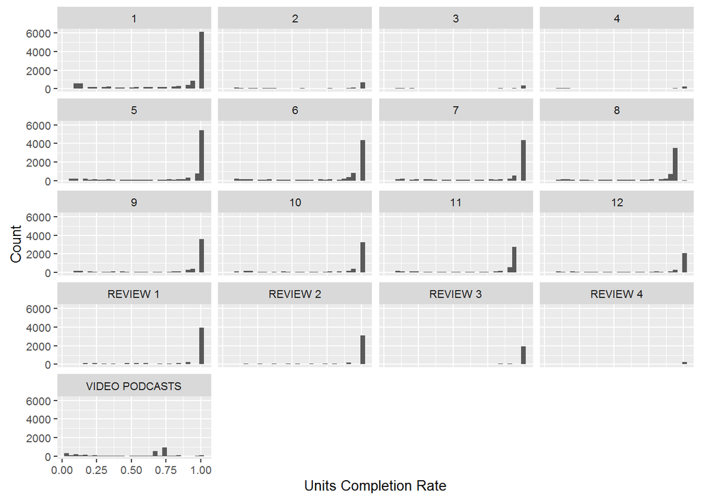

```r
completion <- qplot(x = completion, data = dt) +
  facet_wrap(~unit, ncol = 4) +
  labs(x = "Units Completion Rate", y = "Count")
completion
```

```r
ggsave("completion.png", plot = completion)
```

#### Question 2.1: Which country performs best?

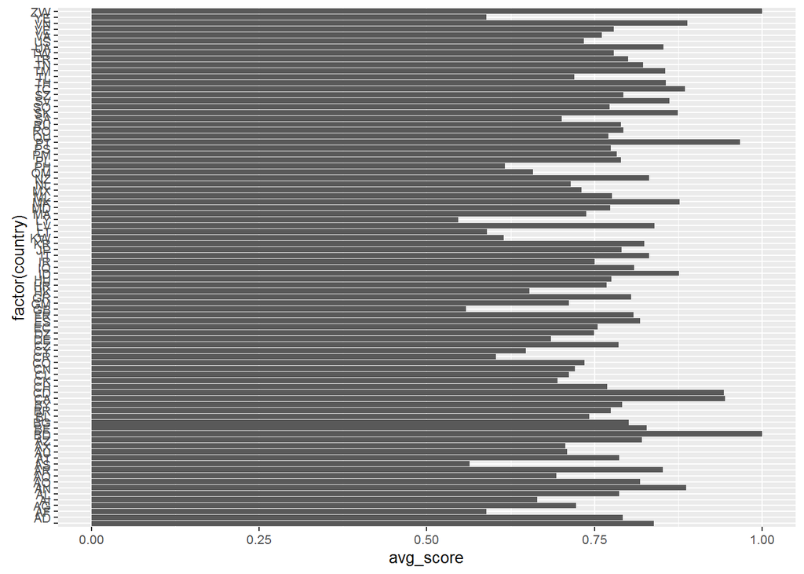

```r
#install.packages("tidyr")
library(tidyr)
library(dplyr)

ggplot(dt, aes(x=factor(country), y=avg_score)) + #mean avg score per country
  stat_summary(fun.y="mean", geom="bar") +
  coord_flip()
```

Since there is great disparity between number of valid observations across the countries, We will choose only countries that have more than 100 observations for further analysis.

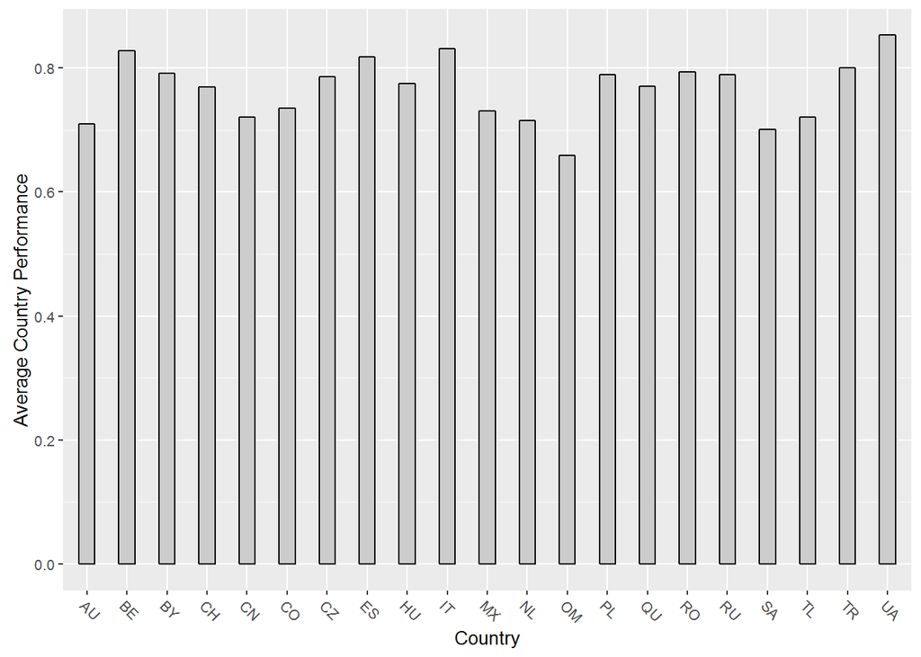

```r
dt2 <- data.frame(dt$country, dt$avg_score) #smaller dt
colnames(dt2) <- c("country", "avg_score")
dt2 <- subset(dt2, dt$country != "") #subet of obs. with known countries


dt3 <- dt2 %>% #wrangling data so that country averages are easier to compute
        group_by(country) %>%
        mutate(id = row_number()) %>%
        spread(country, avg_score) %>%
        select(-id)


stud_num <- apply(dt3, 2, function(x) length(which(!is.na(x)))) #Variable: How many non-NA's is there in a column?
means <- apply(dt3, 2, function(x) mean(x, na.rm = T)) #Variable: Means of average scores for every country
sd <- apply(dt3, 2, function(x) sd(x, na.rm = T))#Variable: Standard Deviation from the mean


dt4 <- data.frame(means, stud_num, sd)#Data frame with new variables


dt5 <- dt4[dt4$stud_num > 100, ] #Data frame with countries that have more than 500 observations
dt5$country <- rownames(dt5) #add Country as variable
rownames(dt5) <- 1:21 #Remove country names from rownames()

dt6 <- with(dt5, dt5[order(means), ]) #sorted by mean, good for quick comparison of countries

mean_plot <- ggplot(dt6, aes(x = country, y = means)) + #bar plot
  geom_bar(stat = "identity", fill = "grey80", colour = "black", width = 0.4) +
  theme(axis.text.x=element_text(angle=-45, hjust=0.001)) +
  labs(y= "Average Country Performance", x = "Country")
mean_plot
```

```r
ggsave("country_means.png", plot = mean_plot)
```

We can observe that countries with the best mean scores are Ukraine (m = 0.85), Italy (m = 0.83) and Belgium (m = 0.82). Oman (m = 0.66), Saudi Arabia (m = 0.70) and Australia (m = 0.71) were the worst from the measured countries.

**KEY INSIGHTS:**

```
1. There is considerable gap between some countries in average     student's scores. European countries on average perform slightly better than countries from other continents.

2. Are courses prepared in accordance with sociocultural demands and experiences of their audiences?

3. Perhaps some courses should be adapted (structurally, linguistically) so that they are more comprehensible for students from outside Western Culture.
```

#### Question 2.2: What country has most rebelious students?

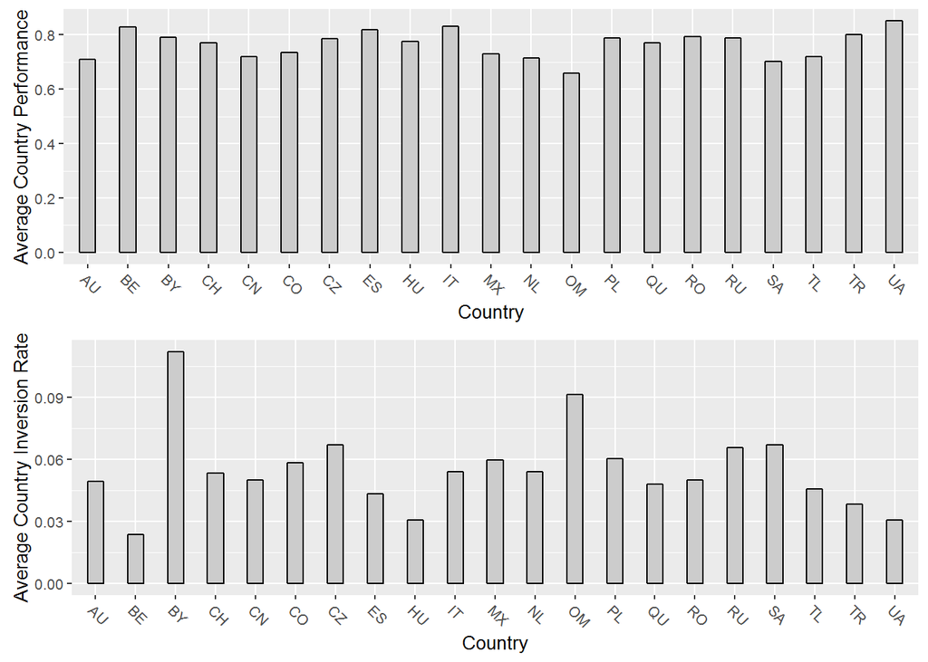

```r
dt2_1 <- data.frame(dt$country, dt$inv_rate) #smaller dt
colnames(dt2_1) <- c("country", "inv_rate")
dt2_1 <- subset(dt2_1, dt$country != "") #subet of obs. with known countries

dt3_1 <- dt2_1 %>% #wrangling data so that country averages are easier to compute
        group_by(country) %>%
        mutate(id = row_number()) %>%
        spread(country, inv_rate) %>%
        select(-id)
m_inv <- apply(dt3_1, 2, function(x) mean(x, na.rm = T))
dt4_1 <- data.frame(m_inv, stud_num)
dt5_1 <- dt4_1[dt4_1$stud_num > 100, ] #Data frame with countries that have more than 500 observations
dt5_1$country <- rownames(dt5_1) #add Country as variable
rownames(dt5_1) <- 1:21 #Remove country names from rownames()

dt6_1 <- with(dt5_1, dt5_1[order(means), ]) #sorted by mean, good for quick comparison of countries

inv_plot <- ggplot(dt6_1, aes(x = country, y = m_inv)) + #bar plot
        geom_bar(stat = "identity", fill = "grey80", colour = "black", width = 0.4) +
        theme(axis.text.x=element_text(angle=-45, hjust=0.001)) +
        labs(y= "Average Country Inversion Rate", x = "Country")

#install.packages("gridExtra")
library(gridExtra)
plots <- grid.arrange(grid.arrange(mean_plot, inv_plot, ncol = 1), padding = 2)
```

```r
ggsave("two_plots_perf_inf.png", plot = plots)
```

Now we can compare visually relation between Inversion Rate and Average Perfromance of students. It catches ones eye that at least some countries with relatively low performance have relatively high inversion rate, and vice versa: Oman on one hand, and Ukraine on the other.

Is there a real correlation between these two variables?

#### Question 3: Does higher inversion rate lower performance?

```r
summary(dt$inv_rate)
```

```
##    Min. 1st Qu.  Median    Mean 3rd Qu.    Max.
## 0.00000 0.00000 0.00000 0.04416 0.02300 1.00000
```

```r
reg2 <- lm(avg_score~inv_rate, data = dt)
summary(reg2)
```

```
##
## Call:
## lm(formula = avg_score ~ inv_rate, data = dt)
##
## Residuals:
##      Min       1Q   Median       3Q      Max
## -0.79666 -0.07366  0.04734  0.13734  0.30578
##
## Coefficients:
##               Estimate Std. Error t value Pr(>|t|)
## (Intercept)  0.7966608  0.0007206 1105.52   <2e-16 ***
## inv_rate    -0.1024428  0.0058050  -17.65   <2e-16 ***
## ---
## Signif. codes:  0 '***' 0.001 '**' 0.01 '*' 0.05 '.' 0.1 ' ' 1
##
## Residual standard error: 0.1922 on 81428 degrees of freedom
##   (2 observations deleted due to missingness)
## Multiple R-squared:  0.00381,    Adjusted R-squared:  0.003798
## F-statistic: 311.4 on 1 and 81428 DF,  p-value: < 2.2e-16
```

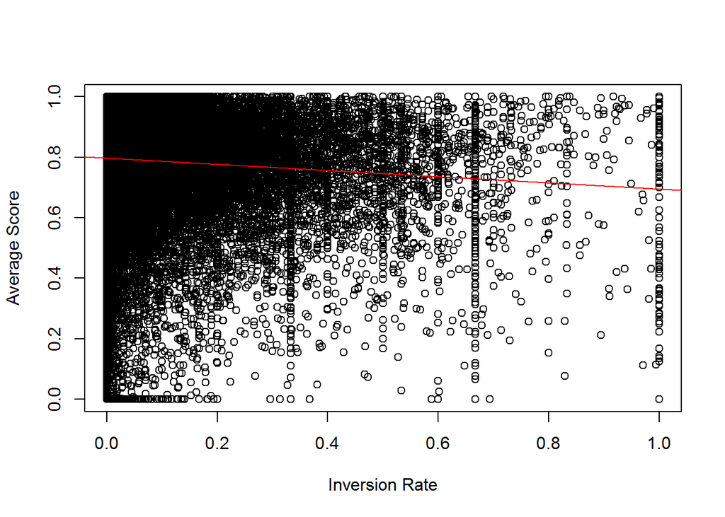

```r
reg_plot <- plot(dt$inv_rate, dt$avg_score, xlab = "Inversion Rate", ylab = "Average Score")
abline(reg2, col="red")
```

```r
ggsave("regression_inv_score.png", plot = reg_plot)
```

As we can see from the regression line above, inverting designed learning order does not help better performance. Students should be encouraged to stay on track.

This leads to another question:

#### Question: 4. Does having a teacher improve performance?

```r
by(dt$avg_score, dt$in_course, summary) #summary of scores for 2 groups (with and without teacher)
```

```
## dt$in_course: f
##    Min. 1st Qu.  Median    Mean 3rd Qu.    Max.    NA's
##  0.0000  0.6670  0.7970  0.7552  0.8890  1.0000       2
## --------------------------------------------------------
## dt$in_course: t
##    Min. 1st Qu.  Median    Mean 3rd Qu.    Max.
##  0.0000  0.7220  0.8430  0.7951  0.9330  1.0000
```

```r
reg <- lm(avg_score~in_course, data = dt) #regression model on two groups
summary(reg)
```

```
##
## Call:
## lm(formula = avg_score ~ in_course, data = dt)
##
## Residuals:
##      Min       1Q   Median       3Q      Max
## -0.79513 -0.07413  0.04687  0.13787  0.24483
##
## Coefficients:
##             Estimate Std. Error t value Pr(>|t|)
## (Intercept) 0.755167   0.002462  306.71   <2e-16 ***
## in_courset  0.039963   0.002560   15.61   <2e-16 ***
## ---
## Signif. codes:  0 '***' 0.001 '**' 0.01 '*' 0.05 '.' 0.1 ' ' 1
##
## Residual standard error: 0.1923 on 81428 degrees of freedom
##   (2 observations deleted due to missingness)
## Multiple R-squared:  0.002984,   Adjusted R-squared:  0.002972
## F-statistic: 243.7 on 1 and 81428 DF,  p-value: < 2.2e-16
```

```r
anova(reg)
```

```
## Analysis of Variance Table
##
## Response: avg_score
##              Df  Sum Sq Mean Sq F value    Pr(>F)
## in_course     1    9.01  9.0094  243.72 < 2.2e-16 ***
## Residuals 81428 3010.07  0.0370
## ---
## Signif. codes:  0 '***' 0.001 '**' 0.01 '*' 0.05 '.' 0.1 ' ' 1
```

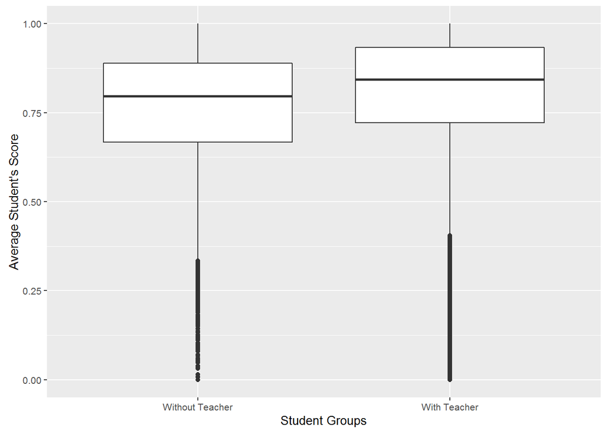

```r
teachers <- ggplot(dt, aes(in_course, avg_score)) + #boxplot comparing two groups
      geom_boxplot() +
      labs(y = "Average Student's Score", x = "Student Groups") +
      scale_x_discrete(labels = c("f" = "Without Teacher", "t" = "With Teacher"))
teachers
```

```r
ggsave("teachers.png", plot = teachers)
```

As we can see from the plots above, tutored group (m = 0.80) has significantly higher scores than group without teacher (m = 0.76) (F(1, 81428) = 243.72, p < .001).

**KEY INSIGHTS:**

1. Students benefit from having a teacher. It’s a good idea to promote this kind of supervised learning.

#### Question 5: Does teacher supervision prevent from inversing the order of learning?

```r
t.test(inv_rate~in_course, data = dt)
```

```
##
##  Welch Two Sample t-test
##
## data:  inv_rate by in_course
## t = 1.8047, df = 6902.2, p-value = 0.07116
## alternative hypothesis: true difference in means is not equal to 0
## 95 percent confidence interval:
##  -0.0002655462  0.0064261440
## sample estimates:
## mean in group f mean in group t
##      0.04700754      0.04392724
```

As we can see from Welsh Two Sample t-test, there was no significatnt difference in Inversion Rate between supervised and unsupervised group.

**KEY INSIGHTS:**

1. Teachers do not play important role in preventing students from inverting the order of learning.

## Summary

Analysis of the data leads to several conclusions:

1. Some countries have better scores than the others. Perhaps cultural differences should be considered when designing learning materials.
2. Students should be encouraged to be disciplined and follow course material in right order.
3. Having a teacher improves students` performance. However, it does not prevent from changing the learning order.